# Модели со смешанными эффектами. Практикум

### Дата занятий: 24 октября

## 1. Постановка задачи и данные

Рассмотрим пример оценивания моделей со смешанными эффектами на кросс-секционных данных из статьи [Luke D.A., Krauss M., 2004], которую Вы можете скачать по [ссылке](https://yadi.sk/i/w_dgDbu8blukXA). Авторы изучают факторы голосования членов Конгресса США в интересах табачной индустрии. В фокусе внимания – различия во взаимосвязи размера финансирования комитетами политического действия (PAC) от табачных корпораций и голосования в интересах табачной индустрии. В частности, авторы тестируют, есть ли различия в этой взаимосвязи между представителями Демократической и Республиканской партий. Воспроизведем часть результатов, полученных в исследовании, а в [домашнем задании](https://politstatistics.github.io/RAPDC_hw2_2023.pdf) Вас ожидает продолжение.

Ниже представлено **краткое описание переменных**:

- state - штат (группирующая переменная)
- lastname - член Конгресса

**Переменные на первом уровне (изменяются по членам Конгресса):**

- votepct - доля голосов, отданных членом Конгресса в поддержку табачной индустрии (зависимая переменная)
- party - дамми-переменная: представитель Демократической или Республиканской партии (1 - Республиканская партия)
- money - размер финансирования от PAC табачных корпораций (в тысячах долларов)

**Предиктор на втором уровне (изменяется по штатам, при этом внутригрупповой изменчивости нет):**

- acres - площадь табачных плантаций (в тысячах акров)

Откроем массив данных, группирующую переменную (штат) сразу для последующего анализа зададим как факторную.

```r
ME<-read_dta("C:/Users/User/OneDrive/Рабочий стол/RAPDC_lab3.dta")

ME$state_id <- as.factor(ME$state)
ME <- na.omit(ME)

head(ME)
```

| house | state | lastname | votepct | party | money | acres | state_id |
| --- | --- | --- | --- | --- | --- | --- | --- |
| 0 | AK | Murkowski | 0.8421053 | 1 | 9.166 | 0 | AK |
| 0 | AK | Stevens | 0.8461538 | 1 | 0.000 | 0 | AK |
| 1 | AK | Young | 0.5714286 | 1 | 23.500 | 0 | AK |
| 0 | AL | Sessions | 0.8717949 | 1 | -0.800 | 0 | AL |
| 0 | AL | Shelby | 0.6410256 | 1 | 24.166 | 0 | AL |
| 1 | AL | Aderholt | 0.9000000 | 1 | 35.000 | 0 | AL |

Как мы видим, данные являются вложенными: более крупные единицы анализа – штаты (2-ой уровень), внутри которых наблюдается изменчивость по членам Конгресса (1-ый уровень). При этом отсылка к такой структуре данных не может быть единственным основанием для оценивания моделей со смешанными эффектами. Не забываем также о том, что для оценивания ME-моделей на втором уровне должно быть достаточно большое количество наблюдений (минимальное количество – порядка 30 для самой базовой экономной спецификации модели, с ростом количества параметров растут требования и к объему выборки). В нашем случае – 50 штатов на втором уровне. Для более полного обоснования мы отмечаем, что интерес представляют различия во взаимосвязи, а не только разные стартовые значения голосования в интересах табачной индустрии: а именно, авторы статьи хотели проверить, есть ли между штатами различия во взаимосвязи финансирования комитетами политического действия от табачных корпораций и голосования в интересах табачной индустрии. Проиллюстрируем различия между штатами на графике ниже:

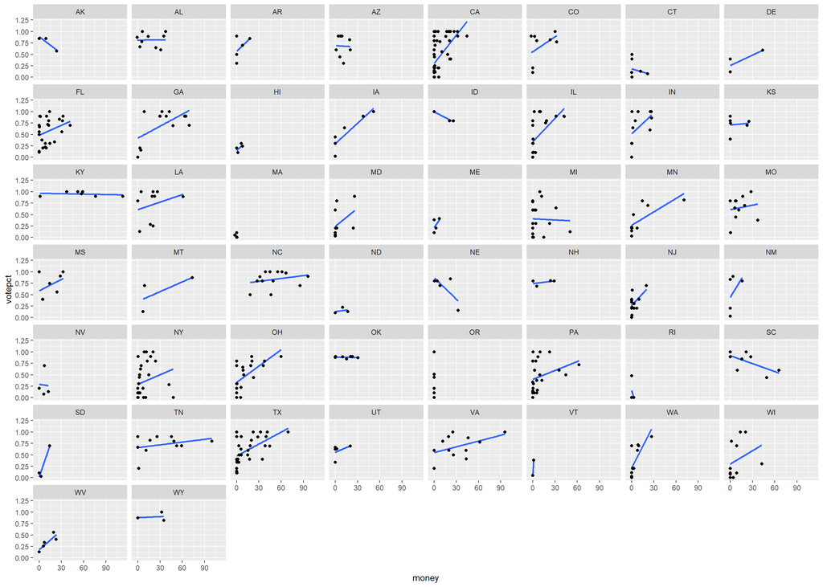

```r
ggplot(ME, aes(x=money, y=votepct)) +
  geom_smooth(method = "lm", se = FALSE) +
  geom_point() +
  facet_wrap("state_id")
```

## 2. Эффект сжатия

Видно, что данные несбалансированные, о чем говорит разное количество наблюдений в штатах. Модель со смешанными эффектами несколько сглаживает ситуацию несбалансированности. Здесь надо вспомнить про так называемый “эффект сжатия” (shrinkage effect). С одной стороны, считается среднее общее по всей выборке (будь то константа или взаимосвязь в среднем) – отсылка к фиксированному эффекту, с другой стороны, считается среднее по j-ой подгруппе (то есть, именно специфика j-ого штата). Если по штату (в более общем смысле – пространственной единице на втором уровне) мало наблюдений, то значения (константы / коэффициента взаимосвязи) для такого штата будет “стягиваться” к среднему общему по всей выборке в силу того, что такой штат рассматривается в рамках ME-модели как “ненадежный”, иными словами, на такую информацию в условиях ограниченного количества наблюдений нельзя полагаться. Кстати, интерактивные картинки того, как происходит “сжатие”, можно посмотреть [здесь](https://m-clark.github.io/posts/2019-05-14-shrinkage-in-mixed-models/).

## 3. Bottom-up strategy

Реализуем стратегию bottom-up при уточнении спецификации модели со смешанными эффектами, то есть, начинаем с простейшей ANOVA-модели, а далее будем последовательно усложнять модель.

**1. ANOVA-модель**

Оценим нулевую модель (то есть, без объясняющих переменных) и рассчитаем на основе полученной информации ICC.

*Пояснение по коду: при использовании lmer для оценивания ME-модели, до скобок записываем фиксированные эффекты, к примеру, в нашем случае используется фиксированный эффект только на константу, поэтому ставим 1; далее в скобках записываем случайные эффекты, так, 1 в скобках означает случайный эффект на константу. Не забываем после вертикальной разделительной черты указать группирующую переменную – штат. Через логический оператор обозначаем, какой метод оценивания используем: REML = FALSE означает, что мы отменяем оценивание через restricted maximum likelihood method (подходит, если у Вас количество наблюдений на втором уровне на грани – 30 или чуть меньше), вместо этого предпочитаем классический MLE*

```r
null <- lmer(votepct ~ 1 + (1|state_id), REML = FALSE, data = ME)
summary(null)
```

```
## Linear mixed model fit by maximum likelihood . t-tests use Satterthwaite's
##   method [lmerModLmerTest]
## Formula: votepct ~ 1 + (1 | state_id)
##    Data: ME
##
##      AIC      BIC   logLik deviance df.resid
##    319.7    332.5   -156.9    313.7      524
##
## Scaled residuals:
##      Min       1Q   Median       3Q      Max
## -2.23742 -0.85315  0.03887  0.75955  2.10386
##
## Random effects:
##  Groups   Name        Variance Std.Dev.
##  state_id (Intercept) 0.03534  0.1880
##  Residual             0.09264  0.3044
## Number of obs: 527, groups:  state_id, 50
##
## Fixed effects:
##             Estimate Std. Error       df t value Pr(>|t|)
## (Intercept)  0.53094    0.03114 45.57848   17.05   <2e-16 ***
## ---
## Signif. codes:  0 '***' 0.001 '**' 0.01 '*' 0.05 '.' 0.1 ' ' 1
```

В выдаче мы видим две части: случайные эффекты (там вариация и для $u_{oj}$, и для остатков на первом уровне – residuals) и фиксированные эффекты (оценка коэффициента константы, составляющая 0.53094 – среднее значение доли голосов в поддержку табачной индустрии по всей выборке). На основе информации, представленной в части Random effects, можем рассчитать ICC, поделив вариацию зависимой переменной на уровне штатов на общую вариацию.

```r
0.03534 / (0.03534+0.09264)
```

```
## [1] 0.2761369
```

Получается, что около 28% изменчивости доли голосов в поддержку табачной индустрии объясняется на уровне штатов, оставшаяся изменчивость – на уровне членов Конгресса.

Можем также получить ICC автоматически следующим образом:

```r
performance::icc(null)
```

```
## # Intraclass Correlation Coefficient
##
##      Adjusted ICC: 0.276
##   Conditional ICC: 0.276
```

Здесь скорректированное значение ICC и без корректировки совпадают, но так бывает не всегда. В дальнейшем Вам понадобится скорректированный ICC.

Казалось бы, все просто: видим значение 0.28 в качестве ICC – делаем вывод о том, что нам нужен такой класс моделей, который работает с неоднородными данными. Однако не стоит торопиться. Вполне может быть так, что значение ICC (примерно 0.28) – результат наличия двух-трех нетипичных наблюдений. Во избежание ошибочной интерпретации и поспешного вывода мы опираемся на следующий график, сравнивающий средние наблюдаемые (те, что в наших данных) с результатами группировки на основе многократного извлечения случайных выборок из имеющейся совокупности данных. Давайте разъясним, что происходит пошагово, и как это отражается на графике ниже.

1. Упорядочиваем исходные наблюдаемые средние по штатам значения доли голосов в поддержку табачной индустрии и располагаем их на графике (так, Вы видите столбцы в порядке возрастания).
2. Генерим случайным образом подгруппы (псевдо-штаты) из имеющейся совокупности данных и считаем средние по полученным подгруппам, упорядочиваем от меньшего к большему. При генерации мы сохраняем количество подгрупп (то есть, в нашем случае – 50 по количеству штатов) и размер исходных выборок.
3. Много раз повторяем процедуру из второго шага. Если Вы посмотрите на код ниже, то сейчас мы задаем 1000 репликаций. Далее усредняем полученные результаты по тысячи репликациям и получаем сглаженную линию с доверительным интервалом, рассчитанным на основе указанной процедуры бутстрэпа (см. график).

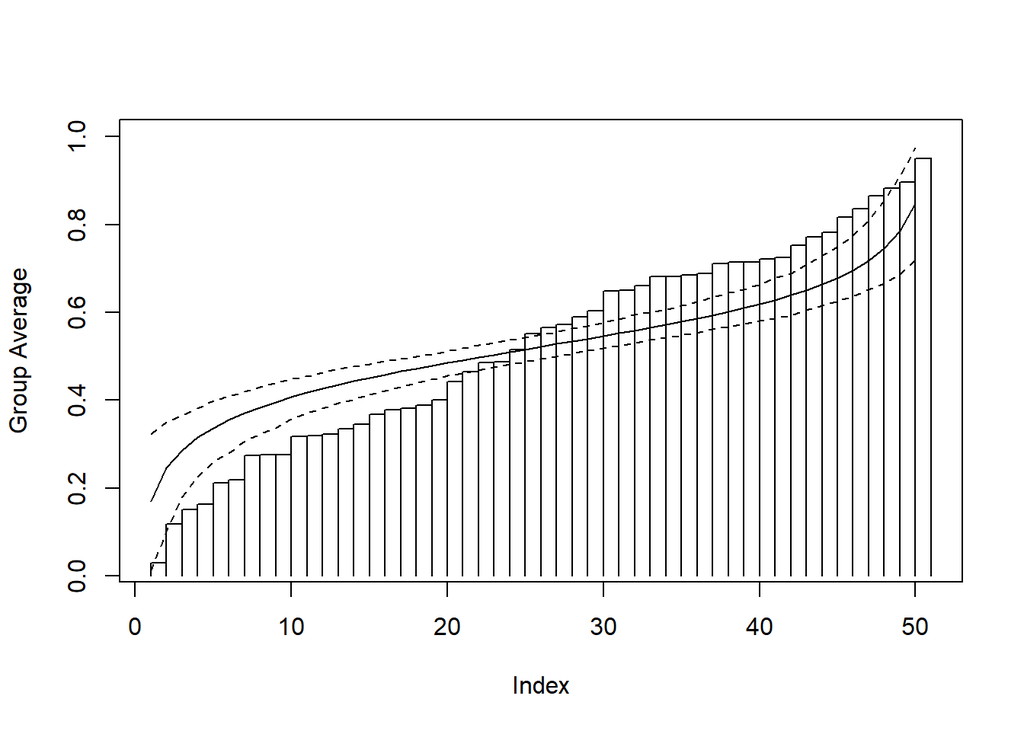

```r
graph.ran.mean(ME$votepct, ME$state_id, nreps=1000, bootci=TRUE)
```

Если края столбцов (наблюдаемые средние) попадают в границы доверительного интервала, то в целом такой результат не отличается от того, что был получен посредством случайного распределения наблюдений на подгруппы. По нашему графику видно, что достаточно много столбцов либо ниже границ доверительного интервала, либо выше, что свидетельствует в пользу неоднородности массива, с которым мы работаем. Если бы практически все столбцы укладывались в границы доверительного интервала, это бы означало, что значимой неоднородности здесь нет, а ICC – результат нескольких выбивающихся нетипичных штатов.

Выгрузку предсказанных значений случайных эффектов (BLUP) можно получить следующим образом:

```r
ranef(null)
```

```
## $state_id
##    (Intercept)
## AK  0.11862432
## AL  0.22093945
## AR  0.07706954
## AZ  0.11410831
## CA -0.08432885
## CO  0.11590471
## CT -0.27682984
## DE -0.08694932
## FL  0.03672017
## GA  0.15004250
## HI -0.19312165
## IA -0.01096309
## ID  0.17824836
## IL -0.03809144
## IN  0.12170401
## KS  0.13242530
## KY  0.30474305
## LA  0.14575977
## MA -0.41172037
## MD -0.16884885
## ME -0.15538418
## MI -0.11329025
## MN -0.11869996
## MO  0.09653619
## MS  0.13394838
## MT  0.01846444
## NC  0.25355886
## ND -0.20275882
## NE  0.08519685
## NH  0.14588531
## NJ -0.18059014
## NM  0.01350197
## NV -0.15383526
## NY -0.17127608
## OH -0.03952206
## OK  0.26547879
## OR -0.15167174
## PA -0.05883805
## RI -0.24919611
## SC  0.18945244
## SD -0.13601415
## TN  0.15722713
## TX  0.06704161
## UT  0.03820302
## VA  0.12892897
## VT -0.13544721
## WA -0.12374887
## WI -0.11458797
## WV -0.12873965
## WY  0.19474048
##
## with conditional variances for "state_id"
```

Так, для Аляски (AK) BLUP для константы составляет 0.1186, то есть, среднее значение доли голосов в поддержку табачной индустрии для Аляски больше на 0.1186, чем среднее по всей выборке.

**2. Добавляем фиксированные эффекты на предикторы**

В первой модели предполагаем, что финансирование от PAC табачных корпораций – значимая объясняющая переменная, при этом пока исходим из простого предположения, что в среднем по всей выборке эффект финансирования одинаковый. В соответствии с этим включаем фиксированный эффект на этот предиктор. Оценим модель, предварительно отменив экспоненциальную запись.

```r
options(scipen = 999)
model1 <- lmer(votepct ~ money + (1|state_id), REML = FALSE, data = ME)
summary(model1)
```

```
## Linear mixed model fit by maximum likelihood . t-tests use Satterthwaite's
##   method [lmerModLmerTest]
## Formula: votepct ~ money + (1 | state_id)
##    Data: ME
##
##      AIC      BIC   logLik deviance df.resid
##    237.6    254.7   -114.8    229.6      523
##
## Scaled residuals:
##      Min       1Q   Median       3Q      Max
## -2.33857 -0.82138 -0.07304  0.78857  2.21384
##
## Random effects:
##  Groups   Name        Variance Std.Dev.
##  state_id (Intercept) 0.01707  0.1307
##  Residual             0.08208  0.2865
## Number of obs: 527, groups:  state_id, 50
##
## Fixed effects:
##                Estimate  Std. Error          df t value            Pr(>|t|)
## (Intercept)   0.4287491   0.0259064  52.4900288  16.550 <0.0000000000000002 ***
## money         0.0076100   0.0007771 500.1512953   9.793 <0.0000000000000002 ***
## ---
## Signif. codes:  0 '***' 0.001 '**' 0.01 '*' 0.05 '.' 0.1 ' ' 1
##
## Correlation of Fixed Effects:
##       (Intr)
## money -0.404
```

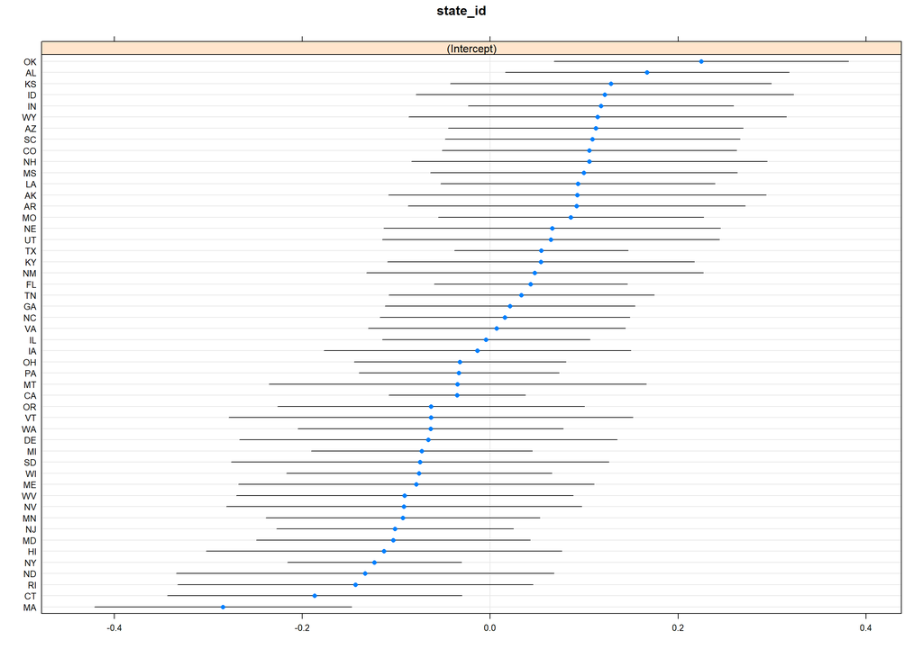

```r
dotplot(ranef(model1, condVar=TRUE))
```

Большинство доверительных интервалов включают 0, и сами доверительные интервалы пересекаются, что говорит в целом о схожести стартовых значений для большинства штатов, с этой точки зрения неоднородности не так уж и много.

В ряде случаев не очень удобно интерпретировать результаты в терминах отклонений, вместо этого хотелось бы сразу получить среднее стартовое значение и взаимосвязь ключевого предиктора и зависимой переменной в j-ой пространственной единице. Рассчитаем оценки констант и коэффициента взаимосвязи финансирования от PAC табачных корпораций и доли голосов в поддержку табачной индустрии для каждого штата. В квадратных скобках обозначим номер параметра, который нас интересует. [,1] – для константы, [,2] – для коэффициента взаимосвязи.

```r
model1_intercept <- coef(model1)$state_id[,1]
model1_slope <- coef(model1)$state_id[,2]
state_unique <- unique(ME$state_id)
data.frame(state_unique, model1_intercept, model1_slope)
```

| state_unique | model1_intercept | model1_slope |
| --- | --- | --- |
| AK | 0.5215831 | 0.007609982 |
| AL | 0.5956589 | 0.007609982 |
| AR | 0.5207073 | 0.007609982 |
| AZ | 0.5410725 | 0.007609982 |
| CA | 0.3934666 | 0.007609982 |
| CO | 0.5342346 | 0.007609982 |
| CT | 0.2419145 | 0.007609982 |
| DE | 0.3627717 | 0.007609982 |
| FL | 0.4717927 | 0.007609982 |
| GA | 0.4497853 | 0.007609982 |

[output cut: 40 more lines]

Мы получили разные константы, при этом для всех штатов одинаковая взаимосвязь. Это обусловлено тем, что когда мы задавали спецификацию модели, мы исходили из предпосылки, что есть значимые отклонения в стартовых точках (случайный эффект на константу), а взаимосвязь финансирования и отклика одинаковая (только фиксированный эффект для переменной money без соответствующего случайного эффекта на наклон).

Продемонстрируем, как можно сравнивать модели. На данном этапе сравним нулевую модель и первую модель. Данные модели являются вложенными: можем получить model1 из нулевой модели посредством добавления параметра – фиксированного эффекта для money. Проверяем гипотезу о равенстве коэффициента при money нулю. Или иными словами, в рамках теста отношения правдоподобия для вложенных моделей мы задаем вопрос, а вносит ли предиктор (money) значимый вклад в объяснение изменчивости доли голосов в поддержку табачной индустрии?

```r
anova(null, model1)
```

|  | npar | AIC | BIC | logLik | deviance | Chisq | Df | Pr(>Chisq) |
| --- | --- | --- | --- | --- | --- | --- | --- | --- |
| null | 3 | 319.7067 | 332.5083 | -156.8533 | 313.7067 | NA | NA | NA |
| model1 | 4 | 237.6333 | 254.7021 | -114.8166 | 229.6333 | 84.07342 | 1 | 0.00000000000000000004767367 |

В выдаче смотрим на статистику $\chi^2$, p-value близко к 0, следовательно, нулевую гипотезу отвергаем. То есть, выбираем модель менее экономную, с включенным предиктором money. Также можно сравнить информационные критерии, показывающие, сколько информации мы теряем. Важно найти баланс между нагруженностью модели и ее информативностью. BIC больше штрафует за добавление параметров по сравнению с AIC. Как по AIC, так и по BIC мы видим, что лучше model1 (так как меньше значения AIC, BIC).

Далее продолжаем расширять спецификацию модели, добавляя партийную принадлежность в качестве предиктора на первом уровне. Опять же исходим из простого допущения о том, что в среднем по всей выборке взаимосвязь партийной принадлежности и доли голосов в поддержку табачной индустрии одинакова, нет различий между штатами. Поэтому в модель вносится фиксированный эффект на партийную принадлежность.

```r
model2 <- lmer(votepct ~ money + party + (1|state_id), REML = FALSE, data = ME)
summary(model2)
```

```
## Linear mixed model fit by maximum likelihood . t-tests use Satterthwaite's
##   method [lmerModLmerTest]
## Formula: votepct ~ money + party + (1 | state_id)
##    Data: ME
##
##      AIC      BIC   logLik deviance df.resid
##   -302.3   -280.9    156.1   -312.3      522
##
## Scaled residuals:
##     Min      1Q  Median      3Q     Max
## -3.3363 -0.5885 -0.0693  0.5980  4.1462
##
## Random effects:
##  Groups   Name        Variance Std.Dev.
##  state_id (Intercept) 0.006192 0.07869
##  Residual             0.029328 0.17125
## Number of obs: 527, groups:  state_id, 50
##
## Fixed effects:
##                Estimate  Std. Error          df t value            Pr(>|t|)
## (Intercept)   0.1997207   0.0172421  76.4322756  11.583 <0.0000000000000002 ***
## money         0.0044760   0.0004758 507.4162925   9.407 <0.0000000000000002 ***
## party         0.4961530   0.0161260 519.2072838  30.767 <0.0000000000000002 ***
## ---
## Signif. codes:  0 '***' 0.001 '**' 0.01 '*' 0.05 '.' 0.1 ' ' 1
##
## Correlation of Fixed Effects:
##       (Intr) money
## money -0.262
## party -0.432 -0.214
```

```r
anova(model1, model2)
```

|  | npar | AIC | BIC | logLik | deviance | Chisq | Df | Pr(>Chisq) |
| --- | --- | --- | --- | --- | --- | --- | --- | --- |
| model1 | 4 | 237.6333 | 254.7021 | -114.8166 | 229.6333 | NA | NA | NA |
| model2 | 5 | -302.2702 | -280.9342 | 156.1351 | -312.2702 | 541.9035 | 1 | 0.000000000000000000000000000000000000000000000000000000000000000000000000000000000000000000000000000000000000000000000007266558 |

Оценки модели показывают, что для республиканцев доля голосов в поддержку табачной индустрии выше в среднем при прочих равных на 0.49 по сравнению с представителями Демократической партии. В соответствии с тестом отношения правдоподобия менее экономная модель (с фиксированным эффектом на партийную принадлежность) более предпочтительна.